# Featurization_model_tuning_Project

```python
import pandas as pd
import numpy as np
import matplotlib.pyplot as mp
import seaborn as sb
from scipy.stats import zscore
from sklearn.model_selection import train_test_split, cross_val_score, RandomizedSearchCV, GridSearchCV
from sklearn.preprocessing import PolynomialFeatures
from sklearn.ensemble import RandomForestRegressor, GradientBoostingRegressor
from scipy.stats import randint
from sklearn.metrics import mean_squared_error, mean_absolute_error,r2_score
from sklearn.linear_model import Lasso
```

```python
dataSet = pd.read_csv("concrete .csv")
dataSet.head(15)
```

|  | cement | slag | ash | water | superplastic | coarseagg | fineagg | age | strength |
| --- | --- | --- | --- | --- | --- | --- | --- | --- | --- |
| 0 | 141.3 | 212.0 | 0.0 | 203.5 | 0.0 | 971.8 | 748.5 | 28 | 29.89 |
| 1 | 168.9 | 42.2 | 124.3 | 158.3 | 10.8 | 1080.8 | 796.2 | 14 | 23.51 |
| 2 | 250.0 | 0.0 | 95.7 | 187.4 | 5.5 | 956.9 | 861.2 | 28 | 29.22 |
| 3 | 266.0 | 114.0 | 0.0 | 228.0 | 0.0 | 932.0 | 670.0 | 28 | 45.85 |
| 4 | 154.8 | 183.4 | 0.0 | 193.3 | 9.1 | 1047.4 | 696.7 | 28 | 18.29 |
| 5 | 255.0 | 0.0 | 0.0 | 192.0 | 0.0 | 889.8 | 945.0 | 90 | 21.86 |
| 6 | 166.8 | 250.2 | 0.0 | 203.5 | 0.0 | 975.6 | 692.6 | 7 | 15.75 |
| 7 | 251.4 | 0.0 | 118.3 | 188.5 | 6.4 | 1028.4 | 757.7 | 56 | 36.64 |
| 8 | 296.0 | 0.0 | 0.0 | 192.0 | 0.0 | 1085.0 | 765.0 | 28 | 21.65 |
| 9 | 155.0 | 184.0 | 143.0 | 194.0 | 9.0 | 880.0 | 699.0 | 28 | 28.99 |
| 10 | 151.8 | 178.1 | 138.7 | 167.5 | 18.3 | 944.0 | 694.6 | 28 | 36.35 |
| 11 | 173.0 | 116.0 | 0.0 | 192.0 | 0.0 | 946.8 | 856.8 | 3 | 6.94 |
| 12 | 385.0 | 0.0 | 0.0 | 186.0 | 0.0 | 966.0 | 763.0 | 14 | 27.92 |
| 13 | 237.5 | 237.5 | 0.0 | 228.0 | 0.0 | 932.0 | 594.0 | 7 | 26.26 |
| 14 | 167.0 | 187.0 | 195.0 | 185.0 | 7.0 | 898.0 | 636.0 | 28 | 23.89 |

```python
dataSet.info()
```

```
<class 'pandas.core.frame.DataFrame'>
RangeIndex: 1030 entries, 0 to 1029
Data columns (total 9 columns):
cement          1030 non-null float64
slag            1030 non-null float64
ash             1030 non-null float64
water           1030 non-null float64
superplastic    1030 non-null float64
coarseagg       1030 non-null float64
fineagg         1030 non-null float64
age             1030 non-null int64
strength        1030 non-null float64
dtypes: float64(8), int64(1)
memory usage: 72.5 KB
```

```
<function matplotlib.pyplot.show(*args, **kw)>
```

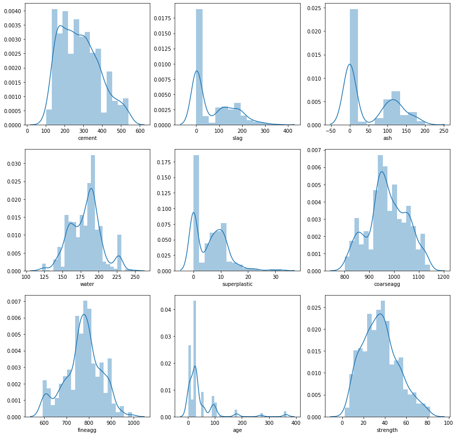

```python
cols = dataSet.columns
mp.figure(figsize=(15,15))
for i in range(1,len(dataSet.columns)+1):
    mp.subplot(3,3,i)
    sb.distplot(dataSet[cols[i-1]])
mp.show
```

**Analysis of the Distribution and Gaussians present in the data**

The above grid of plots showcase the distribution of each of the attribute. In terms of normal distribution only Strength attribute is nearly a normal distribution. In other 8 attributes, we can say that they are mostly skewed and have multiple **gaussians** in them.

1. Cement: A mesokurtic curve which is slightly normal with a multiple gaussians.
2. Slag: A positively skewed data with multiple gaussians.
3. Ash: A positively skewed data with multiple gaussians.
4. Water: Almost normal but has mutiple gaussians.
5. Superplastic: A positively skewed data with multiple gaussian.
6. CoarseAgg: Almost normal but has mutiple gaussians.
7. FineAgg: Almost normal but has mutiple gaussians.
8. Age: A positively skewed data with multiple gaussians.

```python
dataSet.describe()
```

|  | cement | slag | ash | water | superplastic | coarseagg | fineagg | age | strength |
| --- | --- | --- | --- | --- | --- | --- | --- | --- | --- |
| count | 1030.000000 | 1030.000000 | 1030.000000 | 1030.000000 | 1030.000000 | 1030.000000 | 1030.000000 | 1030.000000 | 1030.000000 |
| mean | 281.167864 | 73.895825 | 54.188350 | 181.567282 | 6.204660 | 972.918932 | 773.580485 | 45.662136 | 35.817961 |
| std | 104.506364 | 86.279342 | 63.997004 | 21.354219 | 5.973841 | 77.753954 | 80.175980 | 63.169912 | 16.705742 |
| min | 102.000000 | 0.000000 | 0.000000 | 121.800000 | 0.000000 | 801.000000 | 594.000000 | 1.000000 | 2.330000 |
| 25% | 192.375000 | 0.000000 | 0.000000 | 164.900000 | 0.000000 | 932.000000 | 730.950000 | 7.000000 | 23.710000 |
| 50% | 272.900000 | 22.000000 | 0.000000 | 185.000000 | 6.400000 | 968.000000 | 779.500000 | 28.000000 | 34.445000 |
| 75% | 350.000000 | 142.950000 | 118.300000 | 192.000000 | 10.200000 | 1029.400000 | 824.000000 | 56.000000 | 46.135000 |
| max | 540.000000 | 359.400000 | 200.100000 | 247.000000 | 32.200000 | 1145.000000 | 992.600000 | 365.000000 | 82.600000 |

```
<function matplotlib.pyplot.show(*args, **kw)>
```

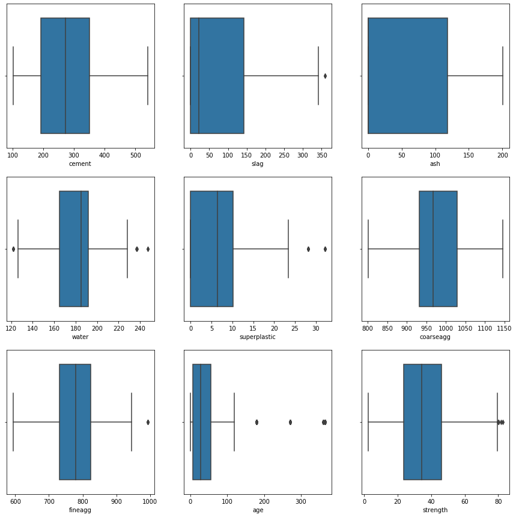

```python
cols = dataSet.columns
mp.figure(figsize=(15,15))
for i in range(1,len(dataSet.columns)+1):
    mp.subplot(3,3,i)
    sb.boxplot(dataSet[cols[i-1]])
mp.show
```

The above grid shows the boxplots of all he attributes of the given data set. Also, the description above shows the 5 point summary of the dataSet that reveals the number outliers that will aftect further. Thus, following attributes have outliers and would be treatred going furhter:

**Slag, Water, Superplastic, FineAgg, Age and Strength.**

Plotting a pairplot of the given dataSet to find relationship between each independent attribute as well as the relationship between the independent attributes and the dependent attribute that is the Strength attribute.

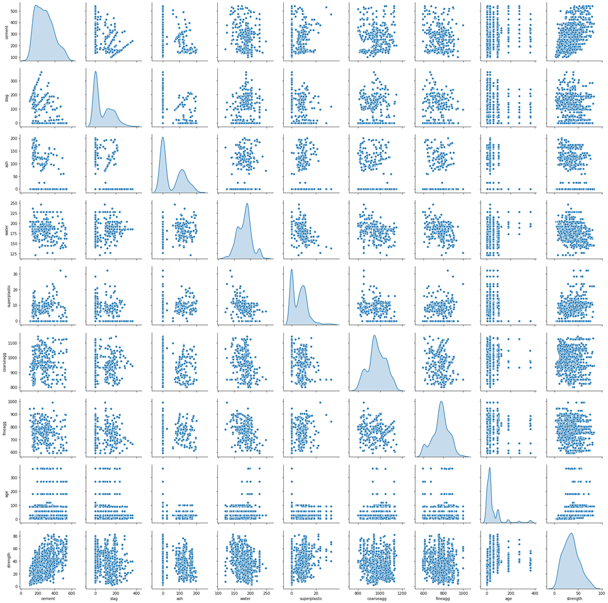

```python
sb.pairplot(dataSet, diag_kind='kde')
```

```python
print("Following is the correlation table of the attributes: ")
dataSet.corr()
```

```
Following is the correlation table of the attributes:
```

|  | cement | slag | ash | water | superplastic | coarseagg | fineagg | age | strength |
| --- | --- | --- | --- | --- | --- | --- | --- | --- | --- |
| cement | 1.000000 | -0.275216 | -0.397467 | -0.081587 | 0.092386 | -0.109349 | -0.222718 | 0.081946 | 0.497832 |
| slag | -0.275216 | 1.000000 | -0.323580 | 0.107252 | 0.043270 | -0.283999 | -0.281603 | -0.044246 | 0.134829 |
| ash | -0.397467 | -0.323580 | 1.000000 | -0.256984 | 0.377503 | -0.009961 | 0.079108 | -0.154371 | -0.105755 |
| water | -0.081587 | 0.107252 | -0.256984 | 1.000000 | -0.657533 | -0.182294 | -0.450661 | 0.277618 | -0.289633 |
| superplastic | 0.092386 | 0.043270 | 0.377503 | -0.657533 | 1.000000 | -0.265999 | 0.222691 | -0.192700 | 0.366079 |
| coarseagg | -0.109349 | -0.283999 | -0.009961 | -0.182294 | -0.265999 | 1.000000 | -0.178481 | -0.003016 | -0.164935 |
| fineagg | -0.222718 | -0.281603 | 0.079108 | -0.450661 | 0.222691 | -0.178481 | 1.000000 | -0.156095 | -0.167241 |
| age | 0.081946 | -0.044246 | -0.154371 | 0.277618 | -0.192700 | -0.003016 | -0.156095 | 1.000000 | 0.328873 |
| strength | 0.497832 | 0.134829 | -0.105755 | -0.289633 | 0.366079 | -0.164935 | -0.167241 | 0.328873 | 1.000000 |

From the box plots above it is clear that the data has multiple outliers. Thus, these outliers should be treated. Also, lets check if there are any missing/ null vlaues in the dataset that may affect the overall distribution of the attributes. The missing values will be treated by replacing them with median of the attibute.

```python
#Checking if there are any missing values in the given dataSet
dataSet.isnull().sum()
```

```
cement          0
slag            0
ash             0
water           0
superplastic    0
coarseagg       0
fineagg         0
age             0
strength        0
dtype: int64
```

From above we can see there are no missing values in the dataSet. However, there are multiple attributes with outliers which are :

Water, Superplastic, FineAgg, Strength

```python
#Treating the outliers using the IQR method:
Q1 = dataSet.quantile(0.25)
Q3 = dataSet.quantile(0.75)
IQR = Q3 - Q1

print ("IQR of the dataSet is: \n")
print (IQR)
```

```
IQR of the dataSet is:

cement          157.625
slag            142.950
ash             118.300
water            27.100
superplastic     10.200
coarseagg        97.400
fineagg          93.050
age              49.000
strength         22.425
dtype: float64
```

```python
dataWithOutliers = ['water', 'superplastic', 'fineagg', 'strength']
for attr in dataWithOutliers:
       for n in range(0,len(dataSet[attr])):
             if dataSet[attr][n] < (Q1[attr]-1.5*IQR[attr]) or dataSet[attr][n] > (Q3[attr]+1.5*IQR[attr]):
                dataSet[attr][n] = dataSet[attr].median()
```

```
<function matplotlib.pyplot.show(*args, **kw)>
```

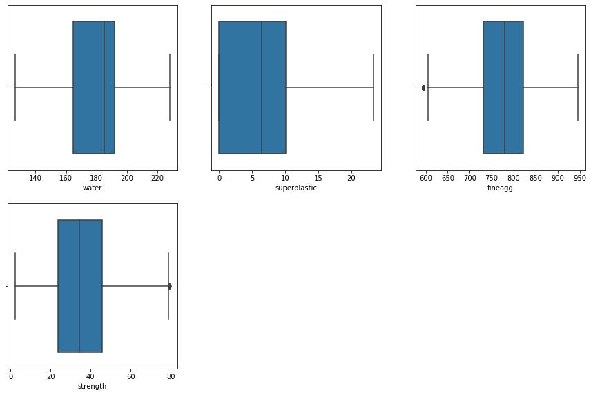

```python
cols = dataWithOutliers
mp.figure(figsize=(15,15))
for i in range(1,len(dataWithOutliers)+1):
    mp.subplot(3,3,i)
    sb.boxplot(dataSet[cols[i-1]])
mp.show
```

Scaling the above data using zscore technique:

```python
dataSet = dataSet.apply(zscore)
```

```python
dataSet.corr()
```

|  | cement | slag | ash | water | superplastic | coarseagg | fineagg | age | strength |
| --- | --- | --- | --- | --- | --- | --- | --- | --- | --- |
| cement | 1.000000 | -0.275216 | -0.397467 | -0.091614 | 0.013336 | -0.109349 | -0.238705 | 0.081946 | 0.493511 |
| slag | -0.275216 | 1.000000 | -0.323580 | 0.099347 | 0.052270 | -0.283999 | -0.289909 | -0.044246 | 0.126729 |
| ash | -0.397467 | -0.323580 | 1.000000 | -0.248011 | 0.447492 | -0.009961 | 0.091735 | -0.154371 | -0.097968 |
| water | -0.091614 | 0.099347 | -0.248011 | 1.000000 | -0.658056 | -0.156928 | -0.426279 | 0.289451 | -0.300039 |
| superplastic | 0.013336 | 0.052270 | 0.447492 | -0.658056 | 1.000000 | -0.224503 | 0.156567 | -0.204384 | 0.342626 |
| coarseagg | -0.109349 | -0.283999 | -0.009961 | -0.156928 | -0.224503 | 1.000000 | -0.161366 | -0.003016 | -0.173233 |
| fineagg | -0.238705 | -0.289909 | 0.091735 | -0.426279 | 0.156567 | -0.161366 | 1.000000 | -0.157209 | -0.176114 |
| age | 0.081946 | -0.044246 | -0.154371 | 0.289451 | -0.204384 | -0.003016 | -0.157209 | 1.000000 | 0.332747 |
| strength | 0.493511 | 0.126729 | -0.097968 | -0.300039 | 0.342626 | -0.173233 | -0.176114 | 0.332747 | 1.000000 |

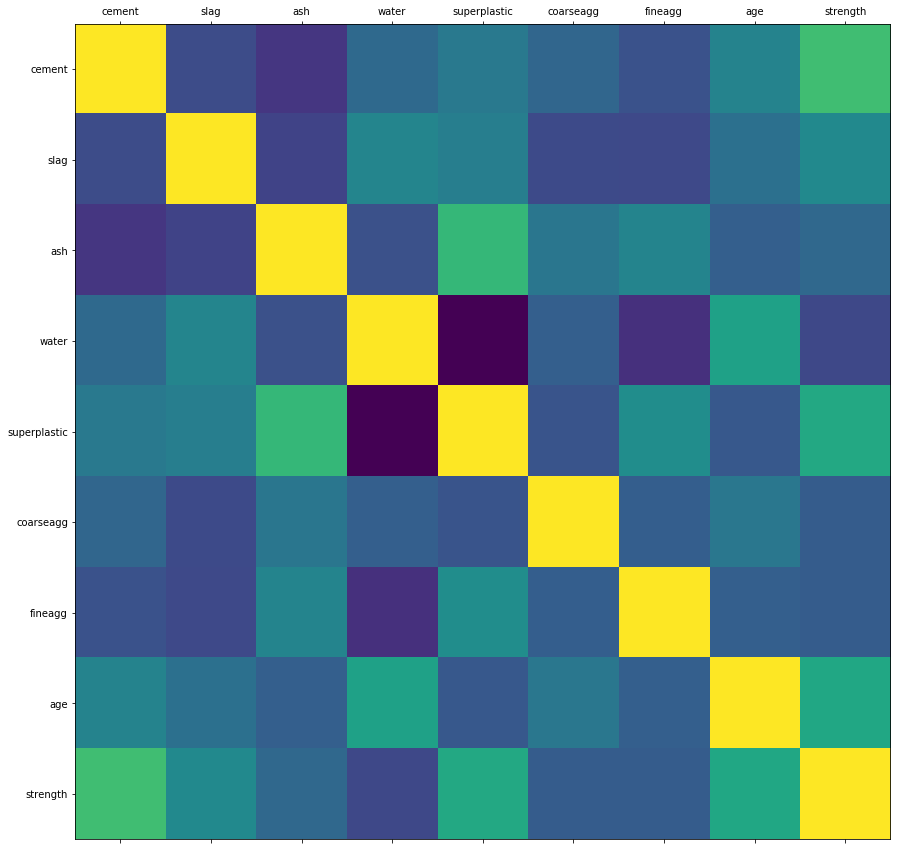

```python
#Plotting a heat map of the above correlation:
def plot_corr(data, size = 15):
    corr = data.corr()
    fig, ax = mp.subplots(figsize = (size, size))
    ax.matshow(corr)
    mp.xticks(range(len(corr.columns)), corr.columns)
    mp.yticks(range(len(corr.columns)), corr.columns)

plot_corr(dataSet)
```

**========================================================================================================================**

```python
X_Vals = dataSet.drop(['strength'], axis =1)
Y_Vals = dataSet['strength']
x_train, x_test, y_train, y_test = train_test_split(X_Vals, Y_Vals, test_size=0.3, random_state=1)
```

```python
def plot_importances(importances, x_vals):
    print("Following are the importances and its plot: " , importances)
    ind = np.argsort(importances)[::-1]
    names = [dataSet.columns[i] for i in ind]
    mp.figure()
    mp.bar(range(x_vals.shape[1]), importances[ind])
    mp.xticks(range(x_vals.shape[1]), names, rotation=90)
    mp.show()
```

Using Random forest and Gradient Boosting regressor models for the given dataSet. Out of these models a better one will be selected.

```python
model_RF = RandomForestRegressor(n_estimators=60)
```

```python
model_RF.fit(x_train,y_train)
```

```
RandomForestRegressor(bootstrap=True, criterion='mse', max_depth=None,
                      max_features='auto', max_leaf_nodes=None,
                      min_impurity_decrease=0.0, min_impurity_split=None,
                      min_samples_leaf=1, min_samples_split=2,
                      min_weight_fraction_leaf=0.0, n_estimators=60,
                      n_jobs=None, oob_score=False, random_state=None,
                      verbose=0, warm_start=False)
```

```python
model_RF.score(x_test,y_test)
```

```
0.8790018803950399
```

```python
importances_RF = model_RF.feature_importances_
```

```
Following are the importances and its plot:  [0.32634927 0.0734008  0.01871189 0.10989085 0.05558264 0.02893957
 0.03603656 0.35108843]
```

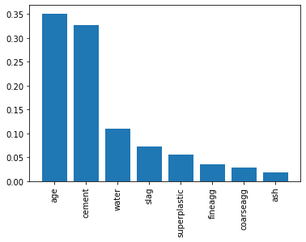

```python
plot_importances(importances=importances_RF ,x_vals=X_Vals)
```

```python
#Now building a Gradient boosting model
model_gb = GradientBoostingRegressor(random_state=1,n_estimators=50 )
```

```python
model_gb.fit(x_train,y_train)
```

```
GradientBoostingRegressor(alpha=0.9, criterion='friedman_mse', init=None,
                          learning_rate=0.1, loss='ls', max_depth=3,
                          max_features=None, max_leaf_nodes=None,
                          min_impurity_decrease=0.0, min_impurity_split=None,
                          min_samples_leaf=1, min_samples_split=2,
                          min_weight_fraction_leaf=0.0, n_estimators=50,
                          n_iter_no_change=None, presort='auto', random_state=1,
                          subsample=1.0, tol=0.0001, validation_fraction=0.1,
                          verbose=0, warm_start=False)
```

```python
model_gb.score(x_test,y_test)
```

```
0.8446424229867241
```

```python
pred = model_gb.predict(x_test)
```

```python
r2_score(y_test,pred)
```

```
0.8446424229867241
```

```python
importances_GB = model_gb.feature_importances_
```

```
Following are the importances and its plot:  [0.31666559 0.06740625 0.02105978 0.10597413 0.06686081 0.0057364
 0.02832892 0.38796813]
```

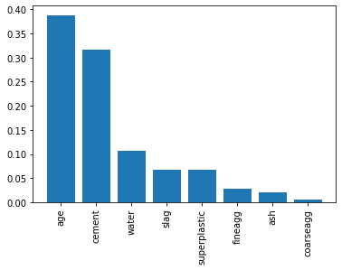

```python
plot_importances(importances = importances_GB ,x_vals= X_Vals)
```

From the above feature importance plots, we can clearly see the features ash and coarseagg contribute very less. Hence, rebuilding the same model by modifying training data. We'll be removing the 'coarseagg' and 'ash' features from the dataSet.

```python
X_mod = dataSet.drop(['strength','ash','coarseagg'],axis=1 ) #Only modifying the independent values. Y_Vals can be reused as it is
```

```python
x_train_mod,x_test_mod,y_train_mod, y_test_mod = train_test_split(X_mod, Y_Vals, random_state=1,test_size=0.3 )
```

Now rebuilding both the models with modified training dataSet as well as using hyper parameter tuning to extract better performance from both the models.

```python
#Building the random forest regression model:
model_RF_mod = RandomForestRegressor()
model_RF_mod=model_RF.fit(x_train_mod,y_train_mod)
```

```python
model_RF_mod.score(x_test_mod,y_test_mod)
```

```
0.8825577973405628
```

```python
pred = model_RF_mod.predict(x_test_mod)
```

```python
r2_score(y_test_mod,pred)
```

```
0.8825577973405629
```

Thus, the random forest model has r2 score of **88.25**

```python
model_RF_mod.get_params
```

```
<bound method BaseEstimator.get_params of RandomForestRegressor(bootstrap=True, criterion='mse', max_depth=None,
                      max_features='auto', max_leaf_nodes=None,
                      min_impurity_decrease=0.0, min_impurity_split=None,
                      min_samples_leaf=1, min_samples_split=2,
                      min_weight_fraction_leaf=0.0, n_estimators=60,
                      n_jobs=None, oob_score=False, random_state=None,
                      verbose=0, warm_start=False)>
```

```python
#Training a random forest with above split data using a random search CV approach to find the best hyper parameter match:
parameters_map = {'bootstrap':[True, False],'max_depth':[5,None],'max_features':randint(1,6),
                  'max_leaf_nodes':randint(2,6),'min_samples_split': randint(2,6),
                  'min_samples_leaf': randint(1,6),'random_state':randint(1,6), 'n_estimators':randint(10,800)
                  }
```

```python
random_cv_RF = RandomizedSearchCV(model_RF_mod, param_distributions=parameters_map, n_iter=150,cv=5)
```

```python
random_cv_RF.fit(x_train_mod,y_train_mod)
```

```
RandomizedSearchCV(cv=5, error_score='raise-deprecating',
                   estimator=RandomForestRegressor(bootstrap=True,
                                                   criterion='mse',
                                                   max_depth=None,
                                                   max_features='auto',
                                                   max_leaf_nodes=None,
                                                   min_impurity_decrease=0.0,
                                                   min_impurity_split=None,
                                                   min_samples_leaf=1,
                                                   min_samples_split=2,
                                                   min_weight_fraction_leaf=0.0,
                                                   n_estimators=60, n_jobs=None,
                                                   oob_score=False,
                                                   random_state=N...
                                        'min_samples_split': <scipy.stats._distn_infrastructure.rv_frozen object at 0x0000024FA3A6B7F0>,
                                        'n_estimators': <scipy.stats._distn_infrastructure.rv_frozen object at 0x0000024FA3A59C88>,
                                        'random_state': <scipy.stats._distn_infrastructure.rv_frozen object at 0x0000024FA3A6BE10>},
                   pre_dispatch='2*n_jobs', random_state=None, refit=True,
                   return_train_score=False, scoring=None, verbose=0)
```

```python
print ("The best parameter match for this random forest model is: ", random_cv_RF.best_params_ )
```

```
The best parameter match for this random forest model is:  {'bootstrap': True, 'max_depth': None, 'max_features': 5, 'max_leaf_nodes': 5, 'min_samples_leaf': 1, 'min_samples_split': 4, 'n_estimators': 15, 'random_state': 5}
```

```python
random_cv_RF.best_score_
```

```
0.6388901643408627
```

```python
r2_score(y_test_mod,random_cv_RF.predict(x_test_mod))
```

```
0.5948040618259147
```

Now trying the GRID SEARCH CV hyperparameter tuning technique.

```python
param_grid = {"max_depth": [3,None],
              "max_features": [1, 3, 6],
              "min_samples_split": [2, 3, 6],
              "min_samples_leaf": [1, 3, 6],
              "bootstrap": [True, False]}
```

```python
grid_search = GridSearchCV(model_RF_mod, param_grid=param_grid)
grid_search.fit(x_train_mod, y_train_mod)
```

```
GridSearchCV(cv='warn', error_score='raise-deprecating',
             estimator=RandomForestRegressor(bootstrap=True, criterion='mse',
                                             max_depth=None,
                                             max_features='auto',
                                             max_leaf_nodes=None,
                                             min_impurity_decrease=0.0,
                                             min_impurity_split=None,
                                             min_samples_leaf=1,
                                             min_samples_split=2,
                                             min_weight_fraction_leaf=0.0,
                                             n_estimators=60, n_jobs=None,
                                             oob_score=False, random_state=None,
                                             verbose=0, warm_start=False),
             iid='warn', n_jobs=None,
             param_grid={'bootstrap': [True, False], 'max_depth': [3, None],
                         'max_features': [1, 3, 6],
                         'min_samples_leaf': [1, 3, 6],
                         'min_samples_split': [2, 3, 6]},
             pre_dispatch='2*n_jobs', refit=True, return_train_score=False,
             scoring=None, verbose=0)
```

```python
grid_search.best_params_
```

```
{'bootstrap': False,
 'max_depth': None,
 'max_features': 3,
 'min_samples_leaf': 1,
 'min_samples_split': 3}
```

```python
print (grid_search.cv_results_['mean_test_score'])
print("\nThe best scoring model is: ", grid_search.best_score_)
```

```
[0.51632511 0.4886176  0.50978965 0.50220307 0.5086219  0.50355769
 0.47473533 0.50771292 0.49253141 0.68907752 0.68261445 0.68098251
 0.67567749 0.67533035 0.67172619 0.68172161 0.67542856 0.67707351
 0.68761639 0.68519052 0.68528585 0.6830715  0.69206875 0.69094276
 0.67836    0.69121969 0.68542181 0.82473636 0.82032089 0.79091821
 0.76888999 0.76012197 0.76434478 0.70054348 0.68950544 0.70759927
 0.87268664 0.86874559 0.86769479 0.8525574  0.85846911 0.85513028
 0.82521442 0.82341369 0.82629041 0.87305541 0.87201356 0.86744112
 0.86593349 0.86147215 0.86436419 0.83510769 0.83658838 0.83456278
 0.52015436 0.52417285 0.51802516 0.49584824 0.49902732 0.50902602
 0.49906672 0.51386983 0.50421185 0.66492893 0.66189263 0.66119399
 0.65676456 0.66350785 0.65886706 0.65856356 0.66734991 0.65823896
 0.54959071 0.54959071 0.54959071 0.54959071 0.54959071 0.54959071
 0.54959071 0.54959071 0.54959071 0.82038213 0.81169776 0.80698461
 0.7810298  0.79035454 0.79478296 0.72228818 0.73022439 0.72953037
 0.87151488 0.87373368 0.86819795 0.86424681 0.86033011 0.85996063
 0.84321095 0.84201549 0.84364084 0.76610076 0.76743788 0.7720743
 0.77668893 0.77638648 0.7763416  0.75681263 0.75685467 0.75686538]

The best scoring model is:  0.8737336795927034
```

```python
r2_score(y_test_mod,grid_search.predict(x_test_mod))
```

```
0.8773179043771129
```

Now, compiling the gradient boost model with modified training data and using hyper parameter training to tune more performance from the model:

```python
#Gradient Boost model
model_gb_mod = GradientBoostingRegressor(max_features=6, random_state=1,min_impurity_decrease=0)
```

```python
model_gb_mod.fit(x_train_mod,y_train_mod)
```

```
GradientBoostingRegressor(alpha=0.9, criterion='friedman_mse', init=None,
                          learning_rate=0.1, loss='ls', max_depth=3,
                          max_features=6, max_leaf_nodes=None,
                          min_impurity_decrease=0, min_impurity_split=None,
                          min_samples_leaf=1, min_samples_split=2,
                          min_weight_fraction_leaf=0.0, n_estimators=100,
                          n_iter_no_change=None, presort='auto', random_state=1,
                          subsample=1.0, tol=0.0001, validation_fraction=0.1,
                          verbose=0, warm_start=False)
```

```python
pred = model_gb_mod.predict(x_test_mod)
```

```python
r2_score(y_test_mod,pred)
```

```
0.868635282844358
```

Using random cv to tune the gradient boosting model:

```python
param_gb = {'loss':['ls', 'lad', 'huber', 'quantile'],
            'learning_rate':[0.1,0.5],
            'n_estimators':randint(10,1500),
             "max_depth": [7, None],
             "max_features": randint(2,7),
             "min_samples_split": randint(2,7),
             "max_leaf_nodes":randint(2,7),
             "min_samples_leaf": randint(2,7),
             "criterion":['mse','friedman_mse'],
             'alpha':[0.5,0.8,0.9],
             'warm_start':[True, False]
             }
```

```python
random_gb = RandomizedSearchCV(model_gb_mod,param_distributions=param_gb, n_iter=250)
```

```python
random_gb.fit(x_train_mod,y_train_mod)
```

```
RandomizedSearchCV(cv='warn', error_score='raise-deprecating',
                   estimator=GradientBoostingRegressor(alpha=0.9,
                                                       criterion='friedman_mse',
                                                       init=None,
                                                       learning_rate=0.1,
                                                       loss='ls', max_depth=3,
                                                       max_features=6,
                                                       max_leaf_nodes=None,
                                                       min_impurity_decrease=0,
                                                       min_impurity_split=None,
                                                       min_samples_leaf=1,
                                                       min_samples_split=2,
                                                       min_weight_fraction_leaf=0.0,
                                                       n_estimators=100,...
                                        'min_samples_leaf': <scipy.stats._distn_infrastructure.rv_frozen object at 0x0000024FA3996B00>,
                                        'min_samples_split': <scipy.stats._distn_infrastructure.rv_frozen object at 0x0000024FA3996F98>,
                                        'n_estimators': <scipy.stats._distn_infrastructure.rv_frozen object at 0x0000024FA3D32A20>,
                                        'warm_start': [True, False]},
                   pre_dispatch='2*n_jobs', random_state=None, refit=True,
                   return_train_score=False, scoring=None, verbose=0)
```

```python
random_gb.best_estimator_
```

```
GradientBoostingRegressor(alpha=0.8, criterion='friedman_mse', init=None,
                          learning_rate=0.1, loss='huber', max_depth=None,
                          max_features=3, max_leaf_nodes=5,
                          min_impurity_decrease=0, min_impurity_split=None,
                          min_samples_leaf=6, min_samples_split=5,
                          min_weight_fraction_leaf=0.0, n_estimators=1416,
                          n_iter_no_change=None, presort='auto', random_state=1,
                          subsample=1.0, tol=0.0001, validation_fraction=0.1,
                          verbose=0, warm_start=True)
```

```python
random_gb.best_score_
```

```
0.9088097579522945
```

```python
pred = random_gb.predict(x_test_mod)
r2_score(y_test_mod,pred)
```

```
0.8977406542818708
```

Thus, the Gradient boosting model with a hyper tuned parameter has score of **~91%** that is **90.88%**

Hence, for the given dataSet the **gradient boost model** turns out to be most useful and with highest performance.